[Home](https://canholyavkin.github.io) - [Other Posts](https://canholyavkin.github.io/#blog) - Contact

# ClinVar

Samanlıktaki Mıknatıs

**Tıbbi genetik ile uğraşan herkesin yolu bir şekilde onunla kesişiyor.** Kimi zaman yetersiz bulsak da, bu veritabanını tamamen göz ardı edemiyoruz. İçeriği konusunda soru işaretlerimiz olsa da ilk baktığımız yer oluyor. **Peki ClinVar Neden bu kadar popüler ve hakkındaki şüphelerimiz gerçeği yansıtıyor mu?**

# ClinVar nedir?

Temel sorudan başlayalım. ClinVar, **destekleyici kanıtlarla**, insan varyasyonları ve fenotipleri -özellikle klinik olanları- arasındaki ilişkilere ait raporlara erişim sağlayan bir veritabanı. Ücretsiz erişilebilen bu platform, NCBI’ın veritabanı ekosistemi içinde yer alıyor. Temelde, insan varyasyonları ve gözlemlenen tıbbi durumları arasındaki ilişkilere yapılan yorumlara ulaşmayı sağlıyor. ClinVar, ayrıca bu varyasyonların klinik önemlerine ait iddiaları, iddia sahibi kurum hakkında bilgileri ve diğer destekleyici verileri de içeriyor.

[figure not shown]

Örnek bir ClinVar kaydının sayfası. Yakın zaman önce tasarımını yenileyen ClinVar, artık daha kullanıcı dostu ve anlaşılır bir görünüm sunuyor.

ClinVar’ın sağladığı bu bilgiler, başta tıbbi genetik olmak üzere bir çok genetik alanında büyük yarar sağlıyor. Genetik test sonucunda tespit edilen varyantların kalıtsal hastalıklarla olası bağıntılarının kurulmasında ilk yararlanılan kaynaklardan biri olarak kullanılıyor.

# ClinVar’ın içeriği nasıl oluşuyor?

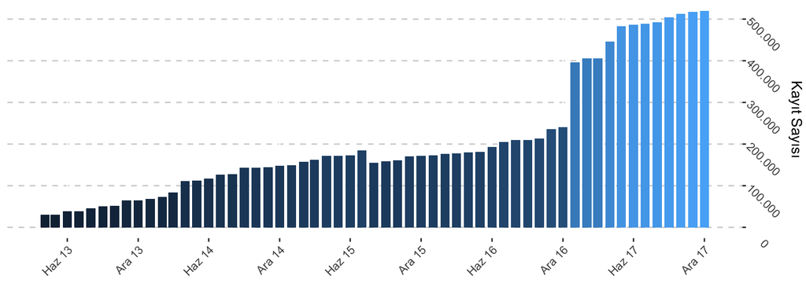

ClinVar’ın kuruluşundan bu yana barındırdığı toplam varyantların değişimi. Veriler 20171207_data_release_notes adlı sürüm notundan alınmıştır. 2017 başındaki büyük sıçrama, Illumina firmasına bağlı Clinical Lab tarafından yapılan devasa boyuttaki katkıdan sonra gerçekleşti.

Öte yandan, araştırma veya klinik hizmet veren bir çok kurum ve enstitü de tespit ettiği bulguları bu veritabanında paylaşabiliyor. **Katılımcı sayısı açısından, ABD (261), Almanya (66) ve Fransa (52) başı çekerken, Türkiye’den veri sağlayan sadece 11 kurum bulunuyor.** Türkiye’deki kurumlar arasında en fazla katkıda bulunan Doç. Dr. Hüseyin Onay’ın laboratuvarı’nın (Ege Üniversitesi) giriş yapmış olduğu 9 adet kayıt bulunuyor. Onu takip eden İstanbul Üniversitesi Aziz Sancar Enstitüsü tarafından da girilmiş 2 adet kayıt yer alıyor.

İşin bir ilginç yanı, ClinVar’daki verilerin çok büyük bir kısmı bu tür üniversiteler tarafından değil, tamamen özel laboratuvarlar tarafından giriliyor. Aşağıda ClinVar’a en fazla katkıda bulunan ilk 10 kurum yer alıyor. Büyük bir çoğunluğunu özel laboratuvarlar oluşturduğu dikkat çekecektir.

- **Illumina Clinical Services Laboratory & Illumina** – 138.336 Kayıt
- **GeneDx** – 98.080 Kayıt
- **Invitaea** – 79.810 Kayıt
- **Ambry Genetics** – 44.860 Kayıt
- **EGL Genetic Diagnostics; Eurofins Clinical Diagnostics** – 37.980 Kayıt
- OMIM; Johns Hopkins University – 28.801 Kayıt
- **Partners HealthCare Personalized Medicine** – 22.095 Kayıt
- **PreventionGenetics** – 15.739 Kayıt
- Genetic Services Laboratory; University of Chicago – 15.338 Kayıt
- **Color Genomics, Inc.** – 10.774 Kayıt

ClinVar’a kayıt girmek için tespit edilen varyant ile ilgili fenotip arasındaki ilişkiyi destekleyici kanıtların bulunması şart. Bunun için 3 yol bulunuyor. **Research**, **Literature Only** veya **Clinical Testing**. Varolan kayıtlar bir araştırma projesi sonucunda bulunmuş ise “research”, literatür üzerinden çekilmiş ise “literature only”, CLIA veya ISO15189 sertifikalı bir laboratuvarın klinik sonucu üzerinden bulunmuş ise “clinical testing” olarak etiketlenerek veritabanındaki yerini alıyor.

# İçeriğinde neler var?

ClinVar, ağırlıklı olarak tek nokta mutasyonlarını barındırsa da, aynı zamanda insersiyon/delesyon verilerine, kopya sayısı değişimlerine, duplikasyonlara ve diğer büyük kromozomal değişimlere de yer veriyor.

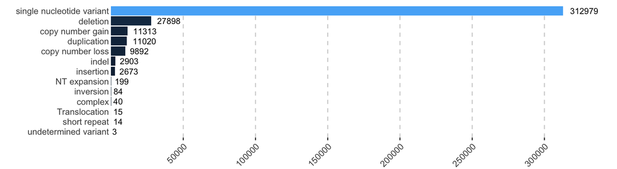

Veritabanı içinde kayıtlı genetik değişimlerin tipleri. Veriler ftp://ftp.ncbi.nlm.nih.gov/pub/clinvar/release_notes/variant_summary.txt adresindeki kayıtlardan derlenmiştir.

Tek nokta değişikliklerini incelediğimizde, ağırlıklı olarak kanser ile ilişkilendirilmiş genlerdeki varyantların raporlandığı açıkça görülüyor.

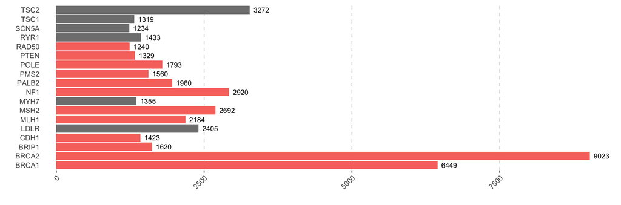

ClinVar’da en fazla kayıt sayısına sahip olan genler. Kırmızı ile gösterilenler çeşitli kanser hastalıkları ile doğrudan veya dolaylı olarak ilişkilendirilmiş genleri ifade ediyor.

# Neden Eleştiriliyor?

ClinVar her ne kadar popüler olsa da içeriğinin güvenilirliği konusunda önemli eleştiriler alıyor. **Bunun en başında çelişkili ve hatta çatışan içeriği geliyor.** Aynı mutasyonu, bir kurum “patojenik” (zararlı) olarak kaydederken, bir farklı kurum “benign” (zararsız) olarak raporlayabiliyor. **Bu şekilde çelişen (conflicting) veriler, tüm kayıtların %4.4’ünü oluşturuyor.** Bu durumda, ilgili varyantın olası etkisini yorumlamak zorlaşıyor.

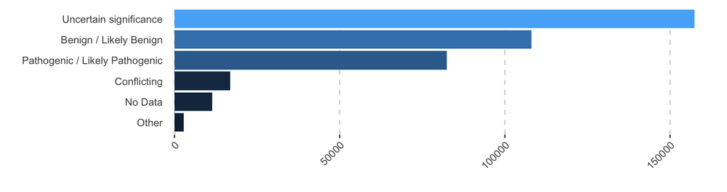

Aynı mutasyona ait yapılan yorumların birbirinden farklı olmasının sebebi, farklı kurumların bir varyantın patojenitesinin belirlenmesinde farklı sınıflandırma algoritmalarını kullanmalarından kaynaklanıyor.

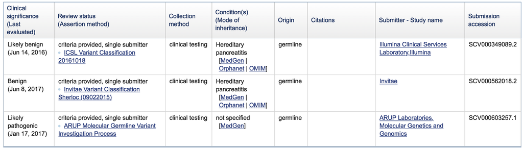

rs140993290 SNP ID’sine sahip varyantın ClinVar kaydı içinde 3 farklı laboratuvarın aynı mutasyon için sırasıyla “Likely Benign”, “Benign” ve “Likely Pathogenic” yorumlarının yapıldığı görülebiliyor.

Diğer taraftan, bir mutasyona ait yorumların sadece tek bir kaynaktan geldiğinde de sorunlar daha fazla artabiliyor. Bir varyanta ait klinik yorumların sadece bir kurum tarafından raporlanması, ilgili varyantın etkisine ait kanıtların da az olduğunu gösteriyor. Ne yazık ki ClinVar üzerinde kayıtlı varyantların %78’inden fazlası sadece 1 kurum tarafından veri girişine sahip. Bu da hata yapma riskini büyük oranda arttırıyor.

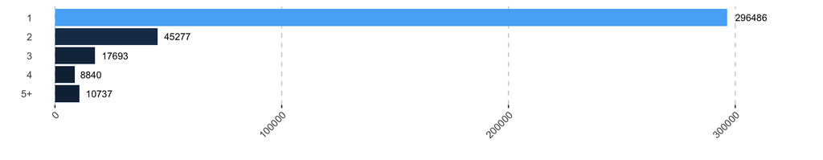

ClinVar üzerinde varyant başına giriş yapılan kurum sayısı. Varyantların büyük bir kısmına ait veriler, sadece birer kurum tarafından sağlanmış.

2018 Nisan ayında J. Craig Venter Ensititüsü tarafından yayınlanan makalede, **kanıt sayısının az olduğu varyantlarda “yanlış” yorumların oldukça fazla olduğu**; kanıt sayısı arttıkça “patojenik” olarak etiketlenen varyantların aslında “benign” olduklarının farkedilmesi de bu durumu kanıtlıyor [^3].

# Neden Vazgeçemiyoruz?

Tam bu noktada önemli bir konudan bahsetmekte fayda var. ClinVar’ı sadece içeriğine göre eleştirmek doğru değil. Çünkü **bu şüpheli içerik aslında yöntemsel hatalardan değil, yöntemsel çeşitlilikten kaynaklanıyor**. Farklı kurumlar, farklı yöntemler kullandığından farklı sonuçlara varabiliyor. Öte yandan, bu veritabanına yeni kayıt girmek için oldukça katı bir kayıt kabul sürecinden geçilmesi gerekiyor. Kayıt sırasında özellikle destekleyici klinik kanıtların açıkça belirtilmesi ve yorumlama yönteminin çok net şekilde ifade edilmesi gerekiyor.

Tüm bunlara rağmen, barındırdığı çelişkili yorumlar hâla önemli bir problem olma özelliğini taşıyor. O halde neden vazgeçemiyoruz? Bunun 2 temel sebebinden bahsedilebilir.

Bunların birincisi elbette **maliyet**. ClinVar tamamen ücretsiz ve öyle kalacak. İçerdiği devasa veriyi açıkça sunarken maddi karşılık istememesi, birçok araştırma laboratuvarı ve tanı merkezi için bulunmaz bir fırsat. ClinVar’ın tam olarak aynı modeli kullanmasa da ticari alternatif veritabanlarının yıllık erişim fiyatlarının çok yüksek olduğu düşünüldüğünde, ücretsiz bir veritabanının avantajı daha iyi anlaşılabilir. Maliyet faktörü bu sebeple içerikteki çelişkilere ağır basıyor.

İkincisi ise **yerel mutasyon veritabanlarının eksikliği**. Çoğu laboratuvar, kendi mutasyon veritabanlarını oluşturacak hasta hacmine veya teknik donanıma sahip olamayabiliyor. Bu durumda, mecburi olarak varolan veritabanlarına yöneliyor. ClinVar ile her laboratuvar, **Ambry Genetics** ve **Invitaea** gibi büyük tanı firmalarının tecrübe ve bilgi birikimlerine (know-how) erişim sağlayabiliyor. Firma içi, ulusal veya uluslararası veritabanlarının eksikliği bu durumu daha da pekiştiriyor.

ClinVar, içeriğindeki çelişkiler sebebiyle hala şüphe ile yaklaşılan bir kaynak. Bu şüpheler, ClinVar’ın varyant yorumlamada yegâne kaynak olarak kullanılmasında hâlen büyük bir engel. Ancak, her geçen gün, bünyesinde biriktirilen destekleyici kanıtlar ile sahip olduğu çelişkiler birer birer azalıyor. Proje devam ettiği sürece, yıllar içinde tüm laboratuvarların her bir varyant için konsensus oluşturabileceği bir platforma dönüşmesi de mümkün. Ancak o zamana kadar, devasa genetik veri samanlığında, aradığımız iğneyi bulmamızı kolaylaştıran etkili ancak küçük bir mıknatıs olmaya devam edecek.

[^1]: Landrum MJ, Lee JM, Riley GR, et al. ClinVar: public archive of relationships among sequence variation and human phenotype. N. 2013;42(D1):D980-D985. doi:10.1093/nar/gkt1113
[^2]: Landrum MJ, Lee JM, Benson M, et al. ClinVar: public archive of interpretations of clinically relevant variants. N. 2015;44(D1):D862-D868. doi:10.1093/nar/gkv1222
[^3]: Shah N, Hou Y-CC, Yu H-C, et al. Identification of Misclassified ClinVar Variants via Disease Population Prevalence. T. 2018;102(4):609-619. doi:10.1016/j.ajhg.2018.02.019

**Can Holyavkin**

E-posta | [Linkedin](https://www.linkedin.com/in/can-holyavkin/) | [Twitter](https://twitter.com/CanHolyavkin)